# Linear Regression-Lab 5Solution

Loading necessary libraries

```python
import numpy as np
import pandas as pd
import sklearn.preprocessing
import matplotlib.pyplot as plt
import seaborn as sns
%matplotlib inline
sns.set()
```

## Linear Data

In this example we'll be using the Boston Housing dataset. There are 506 rows in the dataset. The target variable is median home price. There are 13 predictor variables including average number of rooms per dwelling, crime rate by town, etc. More information about this dataset can be found at https://www.kaggle.com/c/boston-housing

This data frame contains the following columns:

**crim** per capita crime rate by town.

**zn** proportion of residential land zoned for lots over 25,000 sq.ft.

**indus** proportion of non-retail business acres per town.

**chas** Charles River dummy variable (= 1 if tract bounds river; 0 otherwise).

**nox** nitrogen oxides concentration (parts per 10 million).

**rm** average number of rooms per dwelling.

**age** proportion of owner-occupied units built prior to 1940.

**dis** weighted mean of distances to five Boston employment centres.

**rad** index of accessibility to radial highways.

**tax** full-value property-tax rate per $10,000.

**ptratio** pupil-teacher ratio by town.

**black** 1000(Bk - 0.63)^2 where Bk is the proportion of blacks by town.

**lstat** lower status of the population (percent).

**medv** median value of owner-occupied homes in $1000s.

```python
data=pd.read_csv('Boston.csv')
df=data.copy()
```

```python
df.head()
```

|  | Crime Rate | Residential Proportion | non-retail business acres/Town | Charles River | NO2 concentration | Average Rooms/Dwelling. | Prior Built Units Proportion | Distance to Employment Centres | Radial Highways Distance | ValueProperty/tax rate | Teacher/town | blacks/town | Lower Status Percent | median home price |
| --- | --- | --- | --- | --- | --- | --- | --- | --- | --- | --- | --- | --- | --- | --- |
| 0 | 0.00632 | 18.0 | 2.31 | 0.0 | 0.538 | 6.575 | 65.2 | 4.0900 | 1.0 | 296.0 | 15.3 | 396.90 | 4.98 | 24.0 |
| 1 | 0.02731 | 0.0 | 7.07 | 0.0 | 0.469 | 6.421 | 78.9 | 4.9671 | 2.0 | 242.0 | 17.8 | 396.90 | 9.14 | 21.6 |
| 2 | 0.02729 | 0.0 | 7.07 | 0.0 | 0.469 | 7.185 | 61.1 | 4.9671 | 2.0 | 242.0 | 17.8 | 392.83 | 4.03 | 34.7 |
| 3 | 0.03237 | 0.0 | 2.18 | 0.0 | 0.458 | 6.998 | 45.8 | 6.0622 | 3.0 | 222.0 | 18.7 | 394.63 | 2.94 | 33.4 |
| 4 | 0.06905 | 0.0 | 2.18 | 0.0 | 0.458 | 7.147 | 54.2 | 6.0622 | 3.0 | 222.0 | 18.7 | 396.90 | 5.33 | 36.2 |

### Creating Independent and Dependent Variables

```python
X = df.drop(['median home price'], axis=1)
Y = df[['median home price']]
print(X.shape)
print(Y.shape)
```

```
(506, 13)
(506, 1)
```

### Normalization

```python
# scale the features
from sklearn.preprocessing import MinMaxScaler
min_max_scaler = MinMaxScaler()
x_scaled_minmax = min_max_scaler.fit_transform(X)
X = pd.DataFrame(x_scaled_minmax, columns = X.columns)
X.head()
```

|  | Crime Rate | Residential Proportion | non-retail business acres/Town | Charles River | NO2 concentration | Average Rooms/Dwelling. | Prior Built Units Proportion | Distance to Employment Centres | Radial Highways Distance | ValueProperty/tax rate | Teacher/town | blacks/town | Lower Status Percent |
| --- | --- | --- | --- | --- | --- | --- | --- | --- | --- | --- | --- | --- | --- |
| 0 | 0.000000 | 0.18 | 0.067815 | 0.0 | 0.314815 | 0.577505 | 0.641607 | 0.269203 | 0.000000 | 0.208015 | 0.287234 | 1.000000 | 0.089680 |
| 1 | 0.000236 | 0.00 | 0.242302 | 0.0 | 0.172840 | 0.547998 | 0.782698 | 0.348962 | 0.043478 | 0.104962 | 0.553191 | 1.000000 | 0.204470 |
| 2 | 0.000236 | 0.00 | 0.242302 | 0.0 | 0.172840 | 0.694386 | 0.599382 | 0.348962 | 0.043478 | 0.104962 | 0.553191 | 0.989737 | 0.063466 |
| 3 | 0.000293 | 0.00 | 0.063050 | 0.0 | 0.150206 | 0.658555 | 0.441813 | 0.448545 | 0.086957 | 0.066794 | 0.648936 | 0.994276 | 0.033389 |
| 4 | 0.000705 | 0.00 | 0.063050 | 0.0 | 0.150206 | 0.687105 | 0.528321 | 0.448545 | 0.086957 | 0.066794 | 0.648936 | 1.000000 | 0.099338 |

### Train Test Splitting

```python
from sklearn.model_selection import train_test_split
xtrain ,xtest, ytrain, ytest = train_test_split(X, Y, test_size=0.30, random_state=25,shuffle=True)
print(xtrain.shape, ytrain.shape)
print(xtest.shape, ytest.shape)
```

```
(354, 13) (354, 1)
(152, 13) (152, 1)
```

### Training Model, Predicting & Testing

```python
from sklearn.linear_model import LinearRegression
model = LinearRegression()
```

```python
model.fit(xtrain, ytrain)
```

```
LinearRegression(copy_X=True, fit_intercept=True, n_jobs=None,
         normalize=False)
```

```python
pred = model.predict(xtest)
```

```python
model.coef_
```

```
array([[-10.25416832,   5.05163648,   0.7465737 ,   0.73047106,
         -9.22588505,  21.03952249,  -0.4688927 , -17.04518353,
          8.45182117,  -8.73511563,  -9.26613212,   2.95271586,
        -16.64030396]])
```

```python
model.intercept_
```

```
array([27.43583278])
```

### **Checking r2 by sklearn metric**

R2 is a statistic that will give some information about the goodness of fit of a model. In regression, the R2 coefficient of determination is a statistical measure of how well the regression predictions approximate the real data points. An R2 of 1 indicates that the regression predictions perfectly fit the data.A constant model that always predicts the expected value of y, disregarding the input features, would get a R2 score of 0.0.

```python
from sklearn.metrics import r2_score
test_r2=r2_score(ytest,pred)
```

```python
train_r2=r2_score(ytrain,model.predict(xtrain))
```

```python
print('R2 score for testing:',test_r2 )
print('R2 score for training:',train_r2 )
```

```
R2 score for testing: 0.7133593313710357
R2 score for training: 0.7435787589010061
```

# Decision Trees and Grid Search

Decision Tree is one of the classification algorithm widely used. You will be now applying model on our titanic data set to do predictions. After prediction you will further improve the model by tuning the hyper-parameters.

```python
data_titanic=pd.read_csv('titanic_clean.csv')
df_titanic=data_titanic.copy()
```

**One Hot Encoding**

```python
df_OneHot=pd.get_dummies(df_titanic,columns=['Pclass','Sex','Embarked','Title','GrpSize','FareCat','AgeCat'])
df_OneHot.head()
```

|  | PassengerId | Survived | SibSp | Parch | Pclass_1 | Pclass_2 | Pclass_3 | Sex_female | Sex_male | Embarked_C | ... | FareCat_100+ | FareCat_25-40 | FareCat_40-70 | FareCat_70-100 | FareCat_Oct-25 | AgeCat_0-16 | AgeCat_16-32 | AgeCat_32-48 | AgeCat_48-64 | AgeCat_64+ |
| --- | --- | --- | --- | --- | --- | --- | --- | --- | --- | --- | --- | --- | --- | --- | --- | --- | --- | --- | --- | --- | --- |
| 0 | 1 | 0 | 1 | 0 | 0 | 0 | 1 | 0 | 1 | 0 | ... | 0 | 0 | 0 | 0 | 0 | 0 | 1 | 0 | 0 | 0 |
| 1 | 2 | 1 | 1 | 0 | 1 | 0 | 0 | 1 | 0 | 1 | ... | 0 | 0 | 0 | 1 | 0 | 0 | 0 | 1 | 0 | 0 |
| 2 | 3 | 1 | 0 | 0 | 0 | 0 | 1 | 1 | 0 | 0 | ... | 0 | 0 | 0 | 0 | 0 | 0 | 1 | 0 | 0 | 0 |
| 3 | 4 | 1 | 1 | 0 | 1 | 0 | 0 | 1 | 0 | 0 | ... | 0 | 0 | 1 | 0 | 0 | 0 | 0 | 1 | 0 | 0 |
| 4 | 138 | 0 | 1 | 0 | 1 | 0 | 0 | 0 | 1 | 0 | ... | 0 | 0 | 1 | 0 | 0 | 0 | 0 | 1 | 0 | 0 |

5 rows × 32 columns

```python
df_titanic=df_OneHot.copy()
```

```python
df_titanic.head()
```

|  | PassengerId | Survived | SibSp | Parch | Pclass_1 | Pclass_2 | Pclass_3 | Sex_female | Sex_male | Embarked_C | ... | FareCat_100+ | FareCat_25-40 | FareCat_40-70 | FareCat_70-100 | FareCat_Oct-25 | AgeCat_0-16 | AgeCat_16-32 | AgeCat_32-48 | AgeCat_48-64 | AgeCat_64+ |
| --- | --- | --- | --- | --- | --- | --- | --- | --- | --- | --- | --- | --- | --- | --- | --- | --- | --- | --- | --- | --- | --- |
| 0 | 1 | 0 | 1 | 0 | 0 | 0 | 1 | 0 | 1 | 0 | ... | 0 | 0 | 0 | 0 | 0 | 0 | 1 | 0 | 0 | 0 |
| 1 | 2 | 1 | 1 | 0 | 1 | 0 | 0 | 1 | 0 | 1 | ... | 0 | 0 | 0 | 1 | 0 | 0 | 0 | 1 | 0 | 0 |
| 2 | 3 | 1 | 0 | 0 | 0 | 0 | 1 | 1 | 0 | 0 | ... | 0 | 0 | 0 | 0 | 0 | 0 | 1 | 0 | 0 | 0 |
| 3 | 4 | 1 | 1 | 0 | 1 | 0 | 0 | 1 | 0 | 0 | ... | 0 | 0 | 1 | 0 | 0 | 0 | 0 | 1 | 0 | 0 |
| 4 | 138 | 0 | 1 | 0 | 1 | 0 | 0 | 0 | 1 | 0 | ... | 0 | 0 | 1 | 0 | 0 | 0 | 0 | 1 | 0 | 0 |

5 rows × 32 columns

**Creating dependant and independant variables**

```python
X = df_titanic.drop(['PassengerId','Survived'], axis=1)
Y = df_titanic['Survived']
```

**Splitting training and testing data**

```python
from sklearn.model_selection import train_test_split
```

```python
xtrain, xtest, ytrain, ytest = train_test_split(X, Y, test_size=0.3,random_state=100)
print(xtrain.shape, ytrain.shape)
print(xtest.shape, ytest.shape)
```

```
(623, 30) (623,)
(268, 30) (268,)
```

**Applying Decision Tree Classifier**

```python
from sklearn.tree import DecisionTreeClassifier
```

```python
clf_dt= DecisionTreeClassifier(random_state=100)
```

```python
clf_dt.fit(xtrain,ytrain)
```

```
DecisionTreeClassifier(class_weight=None, criterion='gini', max_depth=None,
            max_features=None, max_leaf_nodes=None,
            min_impurity_decrease=0.0, min_impurity_split=None,
            min_samples_leaf=1, min_samples_split=2,
            min_weight_fraction_leaf=0.0, presort=False, random_state=100,
            splitter='best')
```

```python
dt_pred= clf_dt.predict(xtest)
```

**Feature Importance**

```python
clf_dt.feature_importances_
```

```
array([0.04036989, 0.03962628, 0.05101205, 0.00158498, 0.09172353,
       0.00234297, 0.01591574, 0.00722496, 0.00806423, 0.01161505,
       0.00235752, 0.01038001, 0.39491194, 0.00070289, 0.04324049,
       0.02543868, 0.00124958, 0.05750685, 0.02399639, 0.0170202 ,
       0.00602478, 0.02227452, 0.01375303, 0.01885532, 0.01093385,
       0.02058867, 0.02046738, 0.01299074, 0.02345854, 0.00436894])
```

```python
features_tuple= list(zip(X.columns,clf_dt.feature_importances_))
```

```python
features_tuple
```

```
[('SibSp', 0.040369891850615715),
 ('Parch', 0.03962628392961143),
 ('Pclass_1', 0.051012051128100755),
 ('Pclass_2', 0.0015849840024915992),
 ('Pclass_3', 0.09172352653328185),
 ('Sex_female', 0.002342968179905663),
 ('Sex_male', 0.015915741741394263),
 ('Embarked_C', 0.007224961173431636),
 ('Embarked_Q', 0.008064225733801788),
 ('Embarked_S', 0.011615050804349544),
 ('Title_Master', 0.0023575207772963684),
 ('Title_Miss', 0.010380007013394027),
 ('Title_Mr', 0.3949119410599929),
 ('Title_Mrs', 0.0007028904539717005),
 ('Title_Rare Title', 0.04324048645269969),
 ('GrpSize_couple', 0.02543867645814417),
 ('GrpSize_group', 0.0012495830292830188),
 ('GrpSize_large group', 0.05750685232679566),
 ('GrpSize_solo', 0.0239963876579377),
 ('FareCat_0-10', 0.017020196437828712),
 ('FareCat_100+', 0.006024775319757414),
 ('FareCat_25-40', 0.02227452328696848),
 ('FareCat_40-70', 0.01375303273082835),
 ('FareCat_70-100', 0.01885531535257414),
 ('FareCat_Oct-25', 0.010933851506226425),
 ('AgeCat_0-16', 0.020588673514348437),
 ('AgeCat_16-32', 0.020467377883552396),
 ('AgeCat_32-48', 0.01299074298528891),
 ('AgeCat_48-64', 0.023458539622392378),
 ('AgeCat_64+', 0.004368941053734863)]
```

```python
feature_imp=pd.DataFrame(features_tuple,columns=["Feature Names","Importance"])
feature_imp.head()
```

|  | Feature Names | Importance |
| --- | --- | --- |
| 0 | SibSp | 0.040370 |
| 1 | Parch | 0.039626 |
| 2 | Pclass_1 | 0.051012 |
| 3 | Pclass_2 | 0.001585 |
| 4 | Pclass_3 | 0.091724 |

```python
feature_imp=feature_imp.sort_values("Importance",ascending=False)
feature_imp.head()
```

|  | Feature Names | Importance |
| --- | --- | --- |
| 12 | Title_Mr | 0.394912 |
| 4 | Pclass_3 | 0.091724 |
| 17 | GrpSize_large group | 0.057507 |
| 2 | Pclass_1 | 0.051012 |
| 14 | Title_Rare Title | 0.043240 |

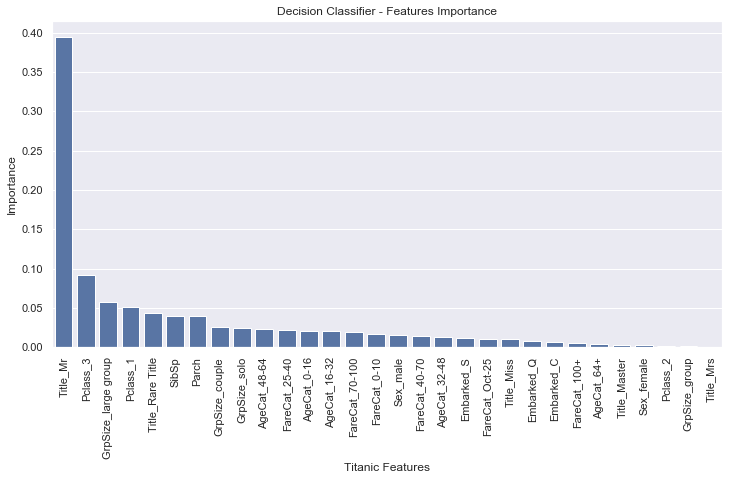

```python
plt.figure(figsize=(12,6))
sns.barplot(x="Feature Names",y="Importance", data=feature_imp, color='b')
plt.xlabel("Titanic Features")
plt.ylabel("Importance")
plt.xticks(rotation=90)
plt.title("Decision Classifier - Features Importance")
```

**Finding accuracy and F1-Score**

```python
from sklearn.metrics import accuracy_score,f1_score
```

```python
accuracy= accuracy_score(ytest,dt_pred)
accuracy
```

```
0.7910447761194029
```

```python
f1score= f1_score(ytest,dt_pred)
f1score
```

```
0.7083333333333334
```

**Applying Grid Search**

```python
from sklearn.model_selection import GridSearchCV
```

Making grid of parameters and running GridSearch CV

```python
param_grid1 = {"criterion":['gini','entropy'],
    "max_depth" : [1, 5, 10, 15, 20, 25, 30],
           "min_samples_split" : [ 2, 4, 6, 8, 10]}

DT = DecisionTreeClassifier(random_state=100)
# Instantiate the GridSearchCV object: logreg_cv
DT_cv1 = GridSearchCV(DT, param_grid1, cv=5,scoring='accuracy',n_jobs=4)

# Fit it to the data
DT_cv1.fit(xtrain,ytrain)

#RF_cv1.cv_results_,
DT_cv1.best_params_, DT_cv1.best_score_
```

```
({'criterion': 'gini', 'max_depth': 5, 'min_samples_split': 2},
 0.8154093097913323)
```

So we found **'criterion': 'gini', max_depth': 5, 'min_samples_split': 2** as optimum parameters

Let's try new set of parameter values near to optimum.

```python
param_grid2 = {"max_depth" : [1,2,3,4,5,6,7,8,9,10],
           "min_samples_split" : [2,3,4]}

DT = DecisionTreeClassifier(random_state=100)
# Instantiate the GridSearchCV object: logreg_cv
DT_cv2 = GridSearchCV(DT, param_grid2, cv=5,scoring='accuracy',n_jobs=4)

# Fit it to the data
DT_cv2.fit(xtrain,ytrain)

#RF_cv1.cv_results_,
DT_cv2.best_params_, DT_cv2.best_score_
```

```
({'max_depth': 4, 'min_samples_split': 2}, 0.8250401284109149)
```

**Tuned Decision Tree Model**

```python
dt_grid=DT_cv2.best_estimator_
```

```python
dt_grid
```

```
DecisionTreeClassifier(class_weight=None, criterion='gini', max_depth=4,
            max_features=None, max_leaf_nodes=None,
            min_impurity_decrease=0.0, min_impurity_split=None,
            min_samples_leaf=1, min_samples_split=2,
            min_weight_fraction_leaf=0.0, presort=False, random_state=100,
            splitter='best')
```

**Fit and predict**

```python
dt_grid.fit(xtrain,ytrain)
dt_grid_pred=dt_grid.predict(xtest)
```

**Accuracy and F1-Score**

```python
accuracy_tuned= accuracy_score(ytest,dt_grid_pred)
accuracy_tuned
```

```
0.8283582089552238
```

```python
f1_score_tuned= f1_score(ytest,dt_grid_pred)
f1_score_tuned
```

```
0.778846153846154
```

## Model Comparison

```python
comp_dict = {"Model Name":["Decision Tree","Tuned Decision Tree"],
           "Accuracy":[accuracy,accuracy_tuned],"F1-Score":[f1score,f1_score_tuned]}
```

```python
comparison=pd.DataFrame(comp_dict)
comparison
```

|  | Model Name | Accuracy | F1-Score |
| --- | --- | --- | --- |
| 0 | Decision Tree | 0.791045 | 0.708333 |
| 1 | Tuned Decision Tree | 0.828358 | 0.778846 |

```python
sort_df=comparison.sort_values(by=['Accuracy','F1-Score'], ascending=False)
sort_df
```

|  | Model Name | Accuracy | F1-Score |
| --- | --- | --- | --- |
| 1 | Tuned Decision Tree | 0.828358 | 0.778846 |
| 0 | Decision Tree | 0.791045 | 0.708333 |